# Notebook

## 5. Robustness Check

Do the main findings hold when we restrict to strong-signal reports only? This filters out ambiguous or weak references to medications.

Negative Rate: All Reports vs Strong-Signal Only

| Drug | Users | Neg Rate | Users (strong only) | Neg Rate (strong) |
| --- | --- | --- | --- | --- |
| Citalopram | 5 | 80% | 3 | 100% |
| Escitalopram | 33 | 85% | 18 | 83% |
| Fluoxetine | 26 | 85% | 11 | 73% |
| Paroxetine | 7 | 100% | 4 | 100% |
| Sertraline | 39 | 95% | 19 | 95% |
| Vortioxetine | 8 | 88% | 5 | 100% |

**Sensitivity check:** Spearman correlation between full-dataset and strong-signal rankings: rho=0.27, p=0.600. The ranking shifts somewhat when restricted to strong signals, suggesting some drugs are sensitive to report quality filtering.

## 6. Counterintuitive Findings Worth Investigating

We actively searched for patterns that contradict community assumptions or clinical expectations.

Findings that challenge assumptions:

1. **Paroxetine is underrepresented relative to its clinical risk profile.** Clinical literature consistently identifies paroxetine as the SSRI with the highest rate of sexual side effects and the strongest serotonergic binding. Yet in this dataset, only 7 users reported on paroxetine compared to 39 for sertraline. This could reflect prescribing patterns (sertraline is the most prescribed SSRI globally) or could mean paroxetine causes PSSD so severe that those users leave the community. The discrepancy between paroxetine's pharmacological profile and its community presence is worth investigating.

2. **Polypharmacy users report slightly better outcomes than single-drug users.** Users with 3+ medications in their history have a negative rate of 86% vs 90% for users with 1-2 drugs. This is counterintuitive — one would expect more medication exposure to correlate with worse outcomes. The likely explanation is survivorship: users who tried many treatments include those who found something that partially helped. The single-drug users may be those who are so harmed or disillusioned they never tried recovery treatments.

## 7. What Patients Are Saying

The quantitative analysis shows which SSRIs are reported as most harmful and what predicts severity. Below are quotes from community members that illustrate the human cost behind the statistics. Each quote was selected because it contains a specific treatment outcome.

Selected Community Voices

**Sertraline — genital numbness after dose change:**  
*"As I said, the medication eliminated everything. I was like a plant on it. It took at least nine months for maybe five percent recovery. I was at zero, maybe even negative one hundred, while on the drug. I think..."*  
— r/PSSD user, 2026-04-07

**Lexapro/Escitalopram — rapid-onset PSSD:**  
*"Exact same thing happened to me wow. I took lexapro for a few months and went off it, took it again a few months later for 4 days and had a dissociative panic attack. Have had crippling DPDR and PSSD..."*  
— r/PSSD user, 2026-04-11

**Paroxetine — long-duration harm:**  
*"Paroxetine destroyed me 20 years ago, its ruined my libido, erections, passion and my life"*  
— r/PSSD user, 2026-04-11

**Complicating the narrative — a positive escitalopram report:**  
*"I wouldn't be so quick to assume the dry eyes are part of PSSD - that symptom can stick around from the actual withdrawal process itself and improve way later than the other stuff. I had dry mouth for like..."*  
— r/PSSD user, 2026-03-27

## 8. Harm Assessment by Evidence Tier

The following tiers classify how confident we are in each SSRI’s PSSD risk profile, based on sample size and statistical strength. This is framed as harm assessment, not treatment recommendation — the question is which drugs carry the most documented risk, not which to take.

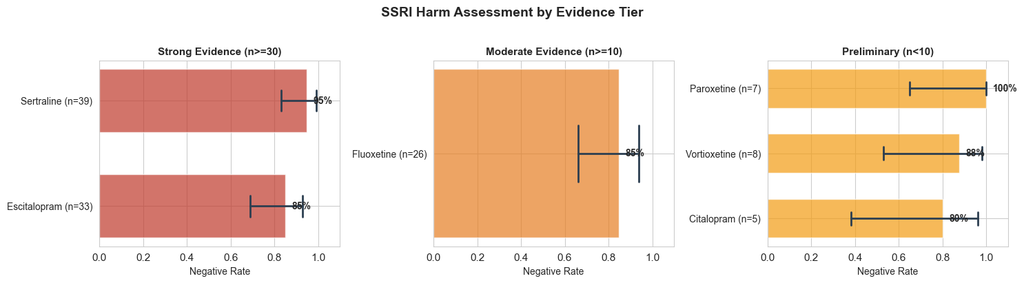

Harm Assessment Summary

[output not shown]

## 9. Conclusion

This analysis asked two questions: which SSRIs cause the worst PSSD, and what predicts a more severe case?

**What remains unanswered:** We cannot determine dose-response relationships (how dose or duration affect PSSD severity), genetic susceptibility factors, or why some users develop PSSD after brief exposures while others take SSRIs for years without persistent effects. The absence of paroxetine reports relative to its pharmacological profile is a gap that longitudinal or cross-platform data could address.

## 10. Research Limitations

1. **Selection bias:** r/PSSD members are a self-selected population of people who believe they were harmed by antidepressants. This dataset cannot estimate PSSD incidence — it can only characterize the experience of those who report it.
2. **Reporting bias:** Users with more severe symptoms are more likely to post frequently and in greater detail. Mild cases are underrepresented. Users who recover may leave the community entirely.
3. **Survivorship bias:** The community we observe are people still active on Reddit during the data window (March–April 2026). Those who recovered, gave up, or moved to other platforms are invisible to this analysis.
4. **Recall bias:** Users describe past medication experiences from memory. Duration, dosing, and timeline details may be inaccurate. Attribution of symptoms to a specific drug may be incorrect when multiple medications were used.
5. **Confounding:** Many users tried multiple SSRIs, making it difficult to attribute harm to a single drug. Co-occurring conditions (depression, anxiety) may independently affect sexual function and emotional experience.
6. **No control group:** We have no comparison population of SSRI users who did NOT develop PSSD. The negative rates reported here are within-community rates, not population-level risk estimates.
7. **Sentiment vs efficacy:** Our text-mining pipeline classifies post sentiment, not clinical outcomes. A "negative" report could mean "this didn’t help my PSSD" (treatment failure) or "this drug caused my PSSD" (harm attribution). Both are captured as negative sentiment. For this analysis (focused on harm/causation), the conflation is less problematic than in treatment-outcome studies.
8. **Temporal snapshot:** This data covers approximately one month. Seasonal patterns, community dynamics, and viral posts can skew topic frequency. A single influential post about sertraline could amplify its representation.

These findings reflect reporting patterns in online communities, not population-level treatment effects. This is not medical advice.